# Magdalena Sudół 276000, Paweł Stępień 276038

```python
import pandas as pd
import matplotlib.pyplot as plt
import numpy as np
from statsmodels.graphics.mosaicplot import mosaic
import scipy.stats
import plot_likert
from statsmodels.stats.proportion import proportions_ztest
from statsmodels.stats.proportion import proportion_confint
import statsmodels.api
```

## Lista 1

### Zadanie 1

```python
data = pd.read_csv('ankieta.csv', encoding='Windows-1250', sep=';')
data.head()
```

|  | DZIAŁ | STAŻ | CZY_KIER | PYT_1 | PYT_2 | PYT_3 | PŁEĆ | WIEK |
| --- | --- | --- | --- | --- | --- | --- | --- | --- |
| 0 | IT | 2 | Nie | 1 | -2 | 1 | M | 64 |
| 1 | IT | 2 | Nie | 0 | -2 | -2 | M | 67 |
| 2 | IT | 2 | Nie | 1 | 2 | 2 | M | 65 |
| 3 | IT | 2 | Nie | -1 | -2 | -2 | K | 68 |
| 4 | IT | 3 | Tak | 1 | 2 | -1 | K | 65 |

```python
#sprawdzenie typów kolumn
data.info()
```

```
<class 'pandas.core.frame.DataFrame'>
RangeIndex: 200 entries, 0 to 199
Data columns (total 8 columns):
 #   Column    Non-Null Count  Dtype
---  ------    --------------  -----
 0   DZIAŁ     200 non-null    object
 1   STAŻ      200 non-null    int64
 2   CZY_KIER  200 non-null    object
 3   PYT_1     200 non-null    int64
 4   PYT_2     200 non-null    int64
 5   PYT_3     200 non-null    int64
 6   PŁEĆ      200 non-null    object
 7   WIEK      200 non-null    int64
dtypes: int64(5), object(3)
memory usage: 12.6+ KB
```

```python
#sprawdzenie, czy występują braki w danych
data.isnull().sum()
```

```
DZIAŁ       0
STAŻ        0
CZY_KIER    0
PYT_1       0
PYT_2       0
PYT_3       0
PŁEĆ        0
WIEK        0
dtype: int64
```

```python
# zmiana typów na kategoryczne
for col in data.select_dtypes(include=['object']).columns:
    data[col] = data[col].astype('category')
```

```python
# podliczenie wartości
for col in data:
    print(data[col].value_counts(dropna=False))
    print()
```

```
DZIAŁ
PD    98
MK    45
HR    31
IT    26
Name: count, dtype: int64

STAŻ
2    140
1     41
3     19
Name: count, dtype: int64

CZY_KIER
Nie    173
Tak     27
Name: count, dtype: int64

PYT_1
 1    100
 0     40
 2     29
-1     17
-2     14
Name: count, dtype: int64

PYT_2
 2    104
-2     74
-1     20
 1      2
Name: count, dtype: int64

PYT_3
 2    86
-2    52
 1    32
-1    30
Name: count, dtype: int64

```

[output cut: 35 more lines]

```
67     2
60     2
27     2
34     2
57     2
29     1
51     1
62     1
59     1
56     1
68     1
63     1
70     1
61     1
Name: count, dtype: int64
```

## Zadanie 2

```python
bins = [0, 35, 45, 55, data["WIEK"].max()]
labels = ["<35", "36-45", "46-55", ">55"]
data["WIEK_KAT"] = pd.cut(data["WIEK"], bins=bins, labels=labels)

data.head(20)
```

|  | DZIAŁ | STAŻ | CZY_KIER | PYT_1 | PYT_2 | PYT_3 | PŁEĆ | WIEK | WIEK_KAT |
| --- | --- | --- | --- | --- | --- | --- | --- | --- | --- |
| 0 | IT | 2 | Nie | 1 | -2 | 1 | M | 64 | >55 |
| 1 | IT | 2 | Nie | 0 | -2 | -2 | M | 67 | >55 |
| 2 | IT | 2 | Nie | 1 | 2 | 2 | M | 65 | >55 |
| 3 | IT | 2 | Nie | -1 | -2 | -2 | K | 68 | >55 |
| 4 | IT | 3 | Tak | 1 | 2 | -1 | K | 65 | >55 |
| 5 | IT | 3 | Tak | 0 | 1 | 1 | K | 57 | >55 |
| 6 | IT | 2 | Tak | 2 | 2 | 1 | K | 57 | >55 |
| 7 | IT | 2 | Tak | 1 | -1 | -2 | K | 58 | >55 |
| 8 | IT | 2 | Nie | 1 | 2 | 2 | K | 56 | >55 |
| 9 | IT | 2 | Nie | 2 | -1 | 1 | K | 47 | 46-55 |
| 10 | IT | 2 | Nie | 2 | -2 | -2 | K | 48 | 46-55 |
| 11 | IT | 2 | Nie | 2 | -2 | -2 | K | 48 | 46-55 |
| 12 | IT | 2 | Tak | 1 | 2 | 2 | K | 48 | 46-55 |
| 13 | IT | 2 | Nie | 1 | 2 | 2 | K | 53 | 46-55 |
| 14 | IT | 2 | Nie | 0 | -2 | -2 | K | 54 | 46-55 |
| 15 | IT | 2 | Nie | 1 | 2 | 2 | K | 37 | 36-45 |
| 16 | IT | 2 | Nie | 0 | -2 | -2 | K | 45 | 36-45 |
| 17 | IT | 2 | Nie | 1 | 2 | 2 | K | 43 | 36-45 |
| 18 | IT | 2 | Nie | 1 | 2 | -1 | K | 34 | <35 |
| 19 | IT | 2 | Nie | 1 | 2 | 2 | K | 27 | <35 |

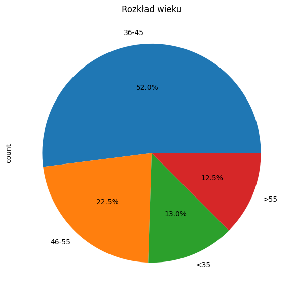

```python
# Tworzenie wykresu kołowego
data['WIEK_KAT'].value_counts().plot(kind='pie', autopct='%1.1f%%', figsize=(7, 7))

# Dodanie tytułu wykresu
plt.title('Rozkład wieku')

# Wyświetlenie wykresu
plt.show()
```

## Zadanie 3

```python
print(data['DZIAŁ'].value_counts(dropna=False))
```

```
DZIAŁ
PD    98
MK    45
HR    31
IT    26
Name: count, dtype: int64
```

Najwięcej osób jest zatrudnionych w dziale PD (Dział Produktowy) - 98 osób. Najmniej osób pracuje w dziale IT (Dział technologii informatycznych)- 26 osób. Poza tym jest dział MK (Dział Marketingu), w którym zatrudnionych jest 45 pracowników oraz dział HR (Dział zasobów ludzkich), gzie pracuje 31 ludzi.

```python
print(data['STAŻ'].value_counts(dropna=False))
```

```
STAŻ
2    140
1     41
3     19
Name: count, dtype: int64
```

W firmie dominują ludzie, których czas zatrudnienia mieści się pomiędzy jednym rokiem a trzema latami. Ich liczba wynosi 140, czyli 70% wszystkich zatrudnionych. Jest także spora grupa osób, których czas stażu jest mniejszy niż jeden rok. Takich osób jest 41, co daje 20,5%. Najmniejszą grupę stanowią zatrudnieni powyżej 3 lat. Takich osób jest jedynie 19, co stanowi 9,5%. Z tych infomacji wynika, że w firmie jest mało doświadczonych osób, a zdecydowaną większość stanowią ludzie z krótkim stażem.

```python
print(data['CZY_KIER'].value_counts(dropna=False))
```

```
CZY_KIER
Nie    173
Tak     27
Name: count, dtype: int64
```

Zmienna CZY_KIER przyjmuje wartości: Tak (stanowisko kierownicze) lub Nie (stanowisko inne niż kierownicze). Możemy zobaczyć, że liczba kierowniczych stanowisk to 27, a pozostałe 173 to zwykli pracownicy. Wygląda to na optymalny stosunek stanowisk kierowniczych względem ilości wszystkich pracowników.

```python
print(data['PŁEĆ'].value_counts(dropna=False))
```

```
PŁEĆ
M    129
K     71
Name: count, dtype: int64
```

W firmie widać zdecydowaną dysproporcję płciową. Jest dużo więcej mężczyzn niż kobiet. Liczba mężczyzn wynosi 129, co stanowi 64,5%. Kobiet jest natomiast 71, co daje 35,5%.

```python
print(data['WIEK_KAT'].value_counts(dropna=False))
```

```
WIEK_KAT
36-45    104
46-55     45
<35       26
>55       25
Name: count, dtype: int64
```

Możemy rozważyć teraz wiek pracowników. Najwiekszą grupę stanowią ludzie z przedziału wiekowego 36-45, a ich liczba wynosi 104. Jest to 52% wszystkich pracowników. Drugą najliczniejszą grupą są pracownicy z przedziału 46-55. Jest to 45 osób, co daje 22,5% wszystkich zatrudnionych. Możemy zaobserwować, że zdecydowaną większość pracowników stanowią ludzie średniego wieku (36-45, 46-55). Najmniej liczne są przedziały wiekowe <35 oraz >55, których liczność to odpowiednio 26 oraz 25.

## Zadanie 4

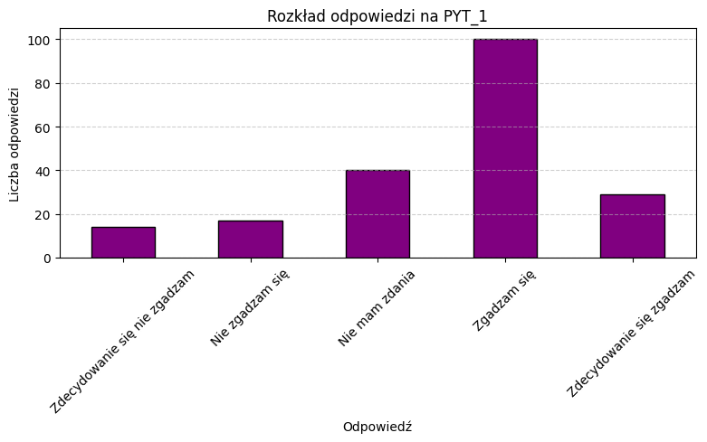

```python
# Mapa wartości liczbowych na etykiety Likerta
likert_labels = {
    -2: "Zdecydowanie się nie zgadzam",
    -1: "Nie zgadzam się",
     0: "Nie mam zdania",
     1: "Zgadzam się",
     2: "Zdecydowanie się zgadzam"
}

# Zliczenie odpowiedzi i mapowanie etykiet
counts_PYT_1 = data['PYT_1'].map(likert_labels).value_counts().reindex(likert_labels.values(), fill_value=0)

# WYKRES
plt.figure(figsize=(8, 5))
counts_PYT_1.plot(kind='bar', color='purple', edgecolor='black')

plt.title('Rozkład odpowiedzi na PYT_1')
plt.xlabel('Odpowiedź')
plt.ylabel('Liczba odpowiedzi')
plt.xticks(rotation=45)
plt.grid(axis='y', linestyle='--', alpha=0.6)

plt.tight_layout()
plt.show()
```

Z wykresu słupkowego możemy odczytać, że największa liczba osób - 100 - udzieliła odpowiedzi "Zgadzam się" na pytanie "Jak bardzo zgadzasz się ze stwierdzeniem, że firma zapewnia odpowiednie wsparcie i materiały umożliwiające skuteczne wykorzystanie w praktyce wiedzy zdobytej w trakcie szkoleń?". 40 osób udzieliło odpowiedzi "Nie mam zdania". Około 30 osób udzieliło odpowiedzi "Zdecydowanie się zgadzam", natomiast najmniej licznymi grupami była grupa osób nie zgadzających się z podanym stwierdzeniem oraz grupa osób zdecydowanie się z nim nie zgadzających - w obu przypadkach było to poniżej 20 osób.

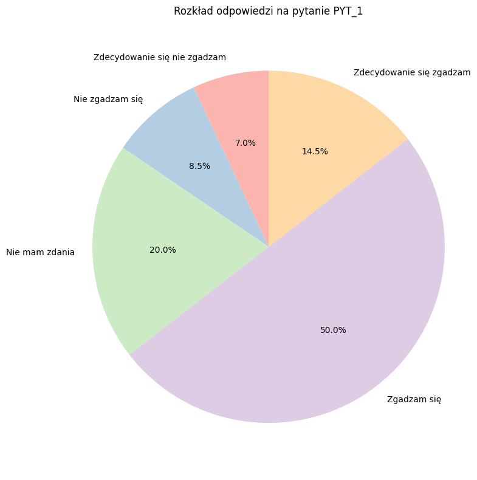

```python
# Wykres kołowy
plt.figure(figsize=(8, 8))
plt.pie(counts_PYT_1, labels=counts_PYT_1.index, autopct='%1.1f%%', startangle=90, colors=plt.cm.Pastel1.colors)
plt.title('Rozkład odpowiedzi na pytanie PYT_1')
plt.axis('equal')
plt.tight_layout()
plt.show()
```

Z wykresu kołowego można odczytać, że osoby, które udzieliły odpowiedzi "Zgadzam się" na pytanie 1, stanowią największą grupę spośród wszystkich, liczącą 50% zatrudnionych. Osoby, które udzieliły odpowiedzi "Nie mam zdania" stanowią 20% zatrudnionych, z kolei osoby zdecydowanie się zgadzające z podanym stwierdzeniem - 14,5% pracowników. Osoby nie zgadzające się z podanym stwierdzeniem stanowią 8,5% wszystkich pracowników, natomiast zdecydowanie się nie zgadzające - 7%.

Na podstawie obydwu wykresów można wywnioskować, że większość pracowników (64,5%) ocenia pozytywnie działania firmy w zakresie zapewnienia odpowiedniego wsparcia i materiałów, umożliwiających skuteczne wykorzystanie w praktyce wiedzy zdobytej w trakcie szkoleń. 20% pracowników nie ma na ten temat zdania, natomiast najmniej liczną grupą są osoby oceniające działania firmy na tym polu negatywnie - grupa ta liczy 15,5% wszystkich zatrudnionych.

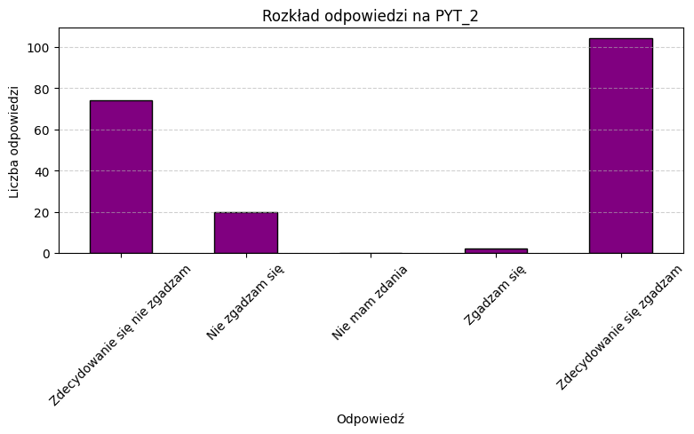

```python
# WYKRES
plt.figure(figsize=(8, 5))

counts_PYT_2 = data['PYT_2'].map(likert_labels).value_counts().reindex(likert_labels.values(), fill_value=0)
counts_PYT_2.plot(kind='bar', color='purple', edgecolor='black')

plt.title('Rozkład odpowiedzi na PYT_2')
plt.xlabel('Odpowiedź')
plt.ylabel('Liczba odpowiedzi')
plt.xticks(rotation=45)
plt.grid(axis='y', linestyle='--', alpha=0.6)

plt.tight_layout()
plt.show()
```

Z wykresu słupkowego można odczytać, że większość zapytanych (ponad 100 osób) zdecydowanie zgadza się ze stwierdzeniem, że firma oferuje szkolenia dostosowane do ich potrzeb, wspierające rozwój zawodowy i szanse na awans. Drugą najliczniejszą grupą są osoby zdecydowanie nie zgadzające się z podanym stwierdzeniem - grupa ta liczy około 75 osób. 20 osób udzieliło odpowiedzi "Nie zgadzam się", natomiast tylko kilka osób zaznaczyło odpowiedź "Zgadzam się".

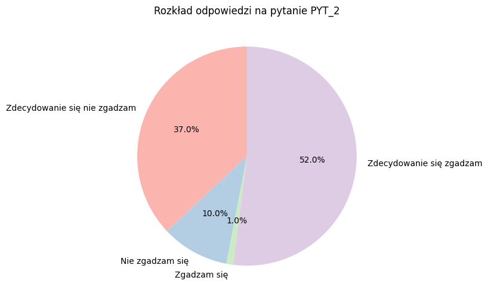

```python
# Usuwanie liczności wartości 'Neutralnie', która nie występuje (liczba wystąpień = 0)
counts_PYT_2 = counts_PYT_2[counts_PYT_2 > 0]
# Wykres kołowy
plt.figure(figsize=(8, 8))
plt.pie(counts_PYT_2, labels=counts_PYT_2.index, autopct='%1.1f%%', startangle=90, colors=plt.cm.Pastel1.colors)
plt.title('Rozkład odpowiedzi na pytanie PYT_2')
plt.tight_layout()
plt.show()
```

Wykres kołowy przedstawia udział procentowy poszczególnych grup wśród wszystkich zapytanych pracowników. Można z niego odczytać, że osoby zdecydowanie zgadzające się ze stwierdzeniem stanowią 52% wszystkich pracowników, osoby zdecydowanie się nie zgadzające - 37% zatrudnionych, osoby nie zgadzające się - 10% pracowników, a zgadzające się stanowią zaledwie 1% wszystkich osób pracujących w firmie.

Z wykresów opisujących odpowiedzi na pytanie 2 wynika, że zdecydowana większość zapytanych podziela jedną ze skrajnych opinii - zdecydowanie się zgadza ze stwierdzeniem bądź zdecydowanie się nie zgadza. Może być to sygnał dla firmy, aby przyjrzeć się temu zagadnieniu i zaproponować odpowiednie działania.

## Zadanie 5

```python
cross_tab_1 = pd.crosstab(data["PYT_1"], data["DZIAŁ"])
cross_tab_1
```

| DZIAŁ PYT_1 | HR | IT | MK | PD |
| --- | --- | --- | --- | --- |
| -2 | 2 | 0 | 3 | 9 |
| -1 | 2 | 2 | 3 | 10 |
| 0 | 5 | 4 | 14 | 17 |
| 1 | 19 | 15 | 15 | 51 |
| 2 | 3 | 5 | 10 | 11 |

Możemy zobaczyć, że większość osób spośród wszystkich działów zgadza się ze stwierdzeniem, iż firma zapewnia odpowiednie wsparcie i materiały umożliwiające skuteczne wykorzystanie w praktyce wiedzy zdobytej w trakcie szkoleń. Zdecydowanie najczęściej pada odpowiedź "Zgadzam się". W miarę często pojawia się również odpowiedź "Zdecydowanie się zgadzam" oraz "Nie mam zdania". Bardzo mało osób ma negatywny stosunek. Jest to bardza mała grupa wględem ilości wszystkich pracowników. Na podstawie tej tablicy firma może przyjąć, że zapewnia odpowiednie wsparcie i materiały umożliwiające skuteczne wykorzystanie w praktyce wiedzy zdobytej w trakcie szkoleń.

```python
cross_tab_2 = pd.crosstab(data["PYT_1"], data["STAŻ"])
cross_tab_2
```

| STAŻ PYT_1 | 1 | 2 | 3 |
| --- | --- | --- | --- |
| -2 | 5 | 5 | 4 |
| -1 | 6 | 10 | 1 |
| 0 | 8 | 26 | 6 |
| 1 | 19 | 75 | 6 |
| 2 | 3 | 24 | 2 |

```python
cross_tab_3 = pd.crosstab(data["PYT_1"], data["CZY_KIER"])
cross_tab_3
```

| CZY_KIER PYT_1 | Nie | Tak |
| --- | --- | --- |
| -2 | 10 | 4 |
| -1 | 14 | 3 |
| 0 | 34 | 6 |
| 1 | 88 | 12 |
| 2 | 27 | 2 |

Po spojrzeniu na tablicę możemy zaobserwować, że zdecydowana większość zgadza się z postawionym twierdzeniem. Zdecydowanie pozytywny stosunek panuje w dużo bardziej licznej grupie ludzi bez stanowisk kierowniczych. Aż 88 osób "Zgadza się" i 27 "Zdecydowanie się zgadza". Tylko 24 pracowników ma negatywny stosunek. Poza tymi dwoma grupami jest spora liczba ludzi do przekonania, ponieważ aż 34 osoby "Nie mają zdania".  
Wśród pracowników zajmujacych kierownicze stanowiska najczęściej pada odpowieź "Zgadzam się". Jest to 12 osób. Jednak na pozostałe odpowiedzi ludzie odpowiadali mniej więcej równomiernie i na każdą inną odpowiedź poza "Zgadzam się" swój głos oddawało po kilka osób. W tej grupie nie ma zdecydowanego nastawienia pozytywnego. Panują ogólnie mieszane opinie.  
Firma może uznać, że ogólnie panuje pozytywna opinia na temat wsparcia. Powinna jednak popracować nad zapewnieniem odpowiedniego wsparcia i materiałów dla kadry kierowniczej. Widać u nich zdecydowanie bardziej stonowane nastroje niż w grupie zwykłych pracowników.

```python
cross_tab_4 = pd.crosstab(data["PYT_1"], data["PŁEĆ"])
cross_tab_4
```

| PŁEĆ PYT_1 | K | M |
| --- | --- | --- |
| -2 | 3 | 11 |
| -1 | 7 | 10 |
| 0 | 14 | 26 |
| 1 | 36 | 64 |
| 2 | 11 | 18 |

Na podstawie tablicy jesteśmy w stanie stwierdzić, że pracwonicy mają pozytywne nastawienie do pytania numer 1. Najliczniejszą grupą zarówno wśród kobiet, jak i mężczyzn, jest odpowiedź "Zgadzam się". Taki głos oddało odpowiednio 36 kobiet i 64 mężczyzn. Jest również po kilkanaście głosów na "Zdecydowanie zgadzam się" wśród obu płci. Negatywnych odpowiedzi jest bardzo mało, jednak w miarę liczną grupę stanowią osoby niezdecydowane. 14 kobiet i 26 mężczyzn zaznaczyło odpowiedź "Nie mam zdania".  
Nie obserwujemy żadnych odmiennych trendów między płciami. Kobiety odpowiadają stosunkowo tak samo często na daną odpowiedź jak mężczyżni. Może to wskazywać, że w firmie panuje równość płciowa i żadna ze stron nie czuje, iż otrzymuje gorsze wsparcie ze strony firmy w zakresie skutecznego wykorzystania w praktyce wiedzy zdobytej podczas szkoleń.

```python
cross_tab_5 = pd.crosstab(data["PYT_1"], data["WIEK_KAT"])
cross_tab_5
```

| WIEK_KAT PYT_1 | <35 | 36-45 | 46-55 | >55 |
| --- | --- | --- | --- | --- |
| -2 | 1 | 11 | 2 | 0 |
| -1 | 6 | 7 | 1 | 3 |
| 0 | 3 | 24 | 5 | 8 |
| 1 | 13 | 50 | 25 | 12 |
| 2 | 3 | 12 | 12 | 2 |

## Zadanie 6

```python
cross_tab_6 = pd.crosstab(data["PYT_2"], data["PYT_3"])
cross_tab_6
```

| PYT_3 PYT_2 | -2 | -1 | 1 | 2 |
| --- | --- | --- | --- | --- |
| -2 | 49 | 16 | 5 | 4 |
| -1 | 3 | 6 | 10 | 1 |
| 1 | 0 | 0 | 2 | 0 |
| 2 | 0 | 8 | 15 | 81 |

Na podstawie tej tablicy wielodzielczej możemy wywnioskować, że zdecydowana większość osób nie zmieniła zdania na temat wsparcia w rozwoju zawodowym i możliwości awansu w firmie: 49 osób oceniło tę kwestię zdecydowanie negatywnie zarówno za pierwszym, jak i za drugim razem; 6 osób oceniło ją negatywnie zarówno za pierwszym, jak i za drugim razem; 2 osoby oceniły tę kwestię pozytywnie w obydwu przypadkach, a 81 osób oceniło ją w obydwu ankietach zdecydowanie pozytywnie. Wśród osób, które miały podczas pierwszej ankiety zdecydowanie negatywne zdanie, 16 zmieniło opinię na negatywną, 5 na pozytywną, a 4 na zdecydowanie pozytywną. Wśród osób, które miały podczas pierwszej ankiety negatywne zdanie, 3 zmieniło opinię na zdecydowanie negatywną, 10 na pozytywną, natomiast 1 na zdecydowanie pozytywną. Osoby oceniające stwierdzenie pozytywnie nie zmieniły zdania pomiędzy pierwszą a drugą ankietą, natomiast wśród osób oceniających stwierdzenie zdecydowanie pozytywnie w pierwszej ankiecie, 15 zmieniło zdanie na pozytywne, a 8 na negatywne. Można zauważyć, że więcej opinii pracowników uległo poprawie niż pogorszeniu, co może wskazywać na to, działania firmy przyniosły w części przypadków pozytywne skutki.

## Zadanie 7

```python
data['CZY_ZADOW'] = np.where(data['PYT_2'].isin([-2, -1]), 'NIE', 'TAK')
data
```

|  | DZIAŁ | STAŻ | CZY_KIER | PYT_1 | PYT_2 | PYT_3 | PŁEĆ | WIEK | WIEK_KAT | CZY_ZADOW |
| --- | --- | --- | --- | --- | --- | --- | --- | --- | --- | --- |
| 0 | IT | 2 | Nie | 1 | -2 | 1 | M | 64 | >55 | NIE |
| 1 | IT | 2 | Nie | 0 | -2 | -2 | M | 67 | >55 | NIE |
| 2 | IT | 2 | Nie | 1 | 2 | 2 | M | 65 | >55 | TAK |
| 3 | IT | 2 | Nie | -1 | -2 | -2 | K | 68 | >55 | NIE |
| 4 | IT | 3 | Tak | 1 | 2 | -1 | K | 65 | >55 | TAK |
| ... | ... | ... | ... | ... | ... | ... | ... | ... | ... | ... |
| 195 | HR | 2 | Nie | 1 | 2 | 2 | M | 42 | 36-45 | TAK |
| 196 | HR | 2 | Nie | 1 | -1 | -1 | K | 35 | <35 | NIE |
| 197 | HR | 2 | Nie | -1 | -2 | -2 | K | 39 | 36-45 | NIE |
| 198 | HR | 2 | Nie | 1 | 2 | 1 | K | 48 | 46-55 | TAK |
| 199 | HR | 2 | Nie | 1 | 2 | 2 | K | 42 | 36-45 | TAK |

200 rows × 10 columns

## Zadanie 8

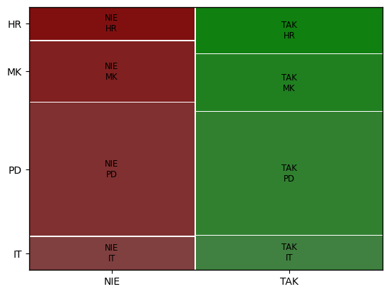

```python
mosaicplot1 = mosaic(data, ["CZY_ZADOW", "DZIAŁ"])
plt.show()
```

Na podstawie powyższego wykresu mozaikowego można postawić hipotezę, że w każdym dziale liczba osób zadowolonych z możliwości rozwoju w firmie oraz osób niezadowolonych jest bardzo zbliżona. W przypadku działu HR mamy do czynienia z małą przewagą osób zadowolonych, natomiast w przypadku działu PD (produktowego) - z małą przewagą osób niezadowolonych.

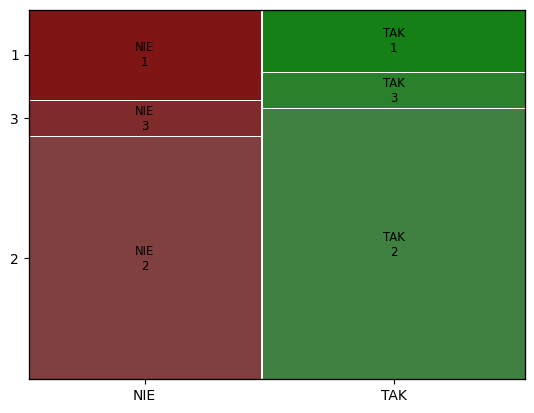

```python
mosaicplot2 = mosaic(data, ["CZY_ZADOW", "STAŻ"])
plt.show()
```

W przypadku podpunktu drugiego możemy zaobserwować, że wśród osób o stażu pracy pomiędzy jednym a trzema latami zarysowuje się przewaga osób zadowolonych z możliwości rozwoju zawodowego, natomiast wśród osób o stażu pracy krótszym niż rok - przewaga osób niezadowolonych.

```
[]
```

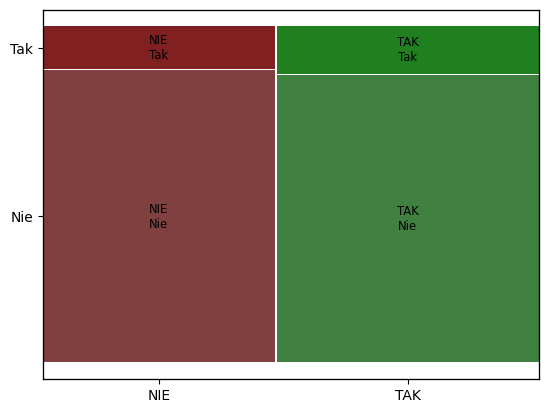

```python
mosaicplot3 = mosaic(data, ["CZY_ZADOW", "CZY_KIER"])
plt.plot()
```

Na podstawie trzeciego wykresu mozaikowego, łączącego stanowisko kierownicze z odpowiedzią udzieloną na pytanie 2, zauważyć można, że poziom zadowolenia z możliwości awansu zawodowego wśród osób niebędących na stanowiskach kierowniczych jest niemalże taki sam jak poziom zadowolenia wśród osób będących na stanowiskach kierowniczych.

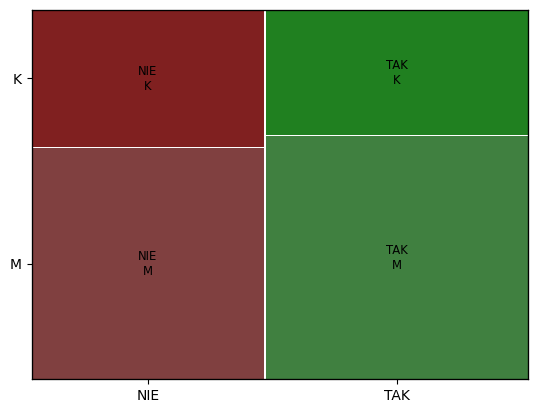

```python
mosaicplot4 = mosaic(data, ["CZY_ZADOW", "PŁEĆ"])
plt.show()
```

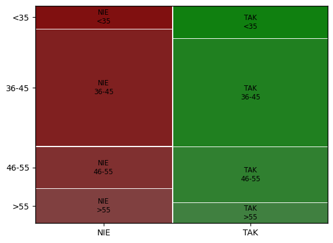

```python
mosaicplot5 = mosaic(data, ["CZY_ZADOW", "WIEK_KAT"])
plt.show()
```

# Część II

## Zadanie 2

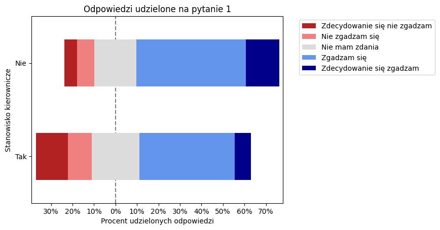

```python
#likert_labels = {-2: "Zdecydowanie się nie zgadzam", -1: "Nie zgadzam się", 0: "Nie mam zdania", 1: "Zgadzam sie", 2: "Zdecydowanie się zgadzam"} - z zadania 4 część 1
data["Pyt_1_odpowiedzi"] = data["PYT_1"].map(likert_labels)
labels = list(likert_labels.values())
data["id_respondenta"] = range(1, len(data) + 1)
data_plot_likert = data.pivot(index="id_respondenta", columns="CZY_KIER", values="Pyt_1_odpowiedzi")

plot_likert.plot_likert(data_plot_likert, labels, plot_percentage = True)
plt.xlabel("Procent udzielonych odpowiedzi")
plt.ylabel("Stanowisko kierownicze")
plt.title("Odpowiedzi udzielone na pytanie 1")
plt.show()
```

## Zadanie 3

```python
### Testowanie działania funkcji ###
# Losowanie 8 liczb od 0 do 9 z powtórzeniami
print(np.random.choice(10, size=8, replace=True))

# Losowanie 3 liter bez powtórzeń
print(np.random.choice(['a', 'b', 'c', 'd'], size=3, replace=False))

### Działanie na pliku "ankieta.csv" ###
# Obliczenie liczności próbki
n_zad_3 = int(len(data) * 0.10)

# Losowanie indeksów ze zwracaniem
indices_with_zad_3 = np.random.choice(data.index, size=n_zad_3, replace=True)
sample_with_replacement_zad_3 = data.loc[indices_with_zad_3]
# Inna opcja
#sample_with_replacement_zad_3 = data.sample(n=n_zad_3 , replace=True)

# Losowanie indeksów bez zwracania
indices_without_zad_3 = np.random.choice(data.index, size=n_zad_3, replace=False)
sample_without_replacement_zad_3 = data.loc[indices_without_zad_3]
#sample_without_replacement_zad_3 = data.sample(n=n_zad_3 , replace=False)

# Sprawdzanie duplikatów
duplicates_with_replacement_zad_3 = sample_with_replacement_zad_3.duplicated()
duplicates_without_replacement_zad_3 = sample_without_replacement_zad_3.duplicated()

# Wyświetlanie wyników
print("Długość pliku 'ankieta.csv':", len(data))

print("\nZwracanie:")
print("Rozmiar:", len(sample_with_replacement_zad_3))
print("Ile wierszy się powtórzyło:", duplicates_with_replacement_zad_3.sum())
print(sample_with_replacement_zad_3.head(3))
```

```
[3 6 3 8 5 6 0 9]
['b' 'd' 'a']
Długość pliku 'ankieta.csv': 200

Zwracanie:
Rozmiar: 20
Ile wierszy się powtórzyło: 2
    DZIAŁ  STAŻ CZY_KIER  PYT_1  PYT_2  PYT_3 PŁEĆ  WIEK WIEK_KAT CZY_ZADOW  \
49     PD     1      Nie      1      2      2    M    44    36-45       TAK
125    MK     2      Nie      1      2      2    K    36    36-45       TAK
4      IT     3      Tak      1      2     -1    K    65      >55       TAK

    Pyt_1_odpowiedzi  id_respondenta
49       Zgadzam się              50
125      Zgadzam się             126
4        Zgadzam się               5
```

```python
print("Bez zwracania:")
print("Rozmiar:", len(sample_without_replacement_zad_3))
print("Ile wierszy się powtórzyło:", duplicates_without_replacement_zad_3.sum())
print(sample_without_replacement_zad_3.head(3))
```

```
Bez zwracania:
Rozmiar: 20
Ile wierszy się powtórzyło: 0
    DZIAŁ  STAŻ CZY_KIER  PYT_1  PYT_2  PYT_3 PŁEĆ  WIEK WIEK_KAT CZY_ZADOW  \
35     PD     1      Nie     -2     -2      1    M    29      <35       NIE
26     PD     2      Tak      1      2      2    M    28      <35       TAK
122    PD     2      Nie      2     -2     -2    M    42    36-45       NIE

                 Pyt_1_odpowiedzi  id_respondenta
35   Zdecydowanie się nie zgadzam              36
26                    Zgadzam się              27
122      Zdecydowanie się zgadzam             123
```

## Zadanie 4

```python
def binomial_sample(n, p, size):
    return np.random.binomial(n, p, size)
```

```python
size = 50
n = 50
p = 0.5

binom_sample = binomial_sample(n, p, size)
```

```python
# wartość oczekiwana:
theoretical_expected_value = n*p
empirical_expected_value = np.mean(binom_sample)

print("Porównanie wartości teoretycznych i empirycznych wartości średniej:")
print(f"Wartość teoretyczna dla n = {n}, p = {p}: {theoretical_expected_value}")
print(f"Wartość empiryczna dla n = {n}, p = {p}: {empirical_expected_value}")
```

```
Porównanie wartości teoretycznych i empirycznych wartości średniej:
Wartość teoretyczna dla n = 50, p = 0.5: 25.0
Wartość empiryczna dla n = 50, p = 0.5: 24.22
```

```python
# wariancja
theoretical_variance = n*p*(1-p)
empirical_variance = np.var(binom_sample)

print("Porównanie wartości teoretycznych i empirycznych wariancji:")
print(f"Wartość teoretyczna dla n = {n}, p = {p}: {theoretical_variance}")
print(f"Wartość empiryczna dla n = {n}, p = {p}: {empirical_variance}")
```

```
Porównanie wartości teoretycznych i empirycznych wariancji:
Wartość teoretyczna dla n = 50, p = 0.5: 12.5
Wartość empiryczna dla n = 50, p = 0.5: 8.931600000000001
```

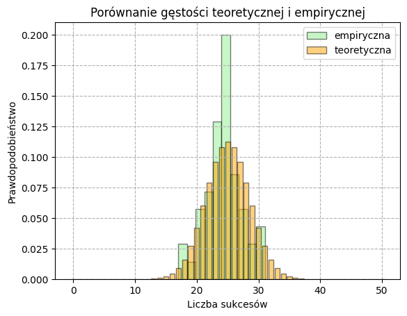

```python
# histogram i gęstość
k = np.arange(size+1)
pmf = scipy.stats.binom.pmf(k, size, p)
plt.hist(binom_sample, color = 'lightgreen', edgecolor = 'black', label = "empiryczna", density = True, alpha = 0.5)
plt.bar(k, pmf, color='orange', edgecolor='black', label = "teoretyczna", alpha = 0.5)
plt.grid(linestyle = "--")
plt.legend()
plt.xlabel("Liczba sukcesów")
plt.ylabel("Prawdopodobieństwo")
plt.title("Porównanie gęstości teoretycznej i empirycznej")
plt.show()
```

## Zadanie 5

```python
def multinomial_sample(n, p, size):
    return np.random.multinomial(n, p, size)
```

```python
size = 100 # liczba symulacji
n = 25 # liczba prób
p = [0.1, 0.2, 0.3, 0.2, 0.1, 0.1] # wektor prawdopodobieństw dla każdej kategorii

multinom_sample = multinomial_sample(n, p, size)
```

```python
# wartość oczekiwana

print("Średnie wartości teoretyczne i empiryczne dla każdego X_i:")
for i in range(len(p)):
    print(f"Wartość teoretyczna dla X_{i+1}: {n*p[i]}")
    print(f"Wartość empiryczna dla X_{i+1}: {np.mean([multinom_sample[k][i] for k in range(size)])}")
```

```
Średnie wartości teoretyczne i empiryczne dla każdego X_i:
Wartość teoretyczna dla X_1: 2.5
Wartość empiryczna dla X_1: 2.36
Wartość teoretyczna dla X_2: 5.0
Wartość empiryczna dla X_2: 4.98
Wartość teoretyczna dla X_3: 7.5
Wartość empiryczna dla X_3: 7.17
Wartość teoretyczna dla X_4: 5.0
Wartość empiryczna dla X_4: 5.21
Wartość teoretyczna dla X_5: 2.5
Wartość empiryczna dla X_5: 2.64
Wartość teoretyczna dla X_6: 2.5
Wartość empiryczna dla X_6: 2.64
```

```python
# wariancja

print("Wariancje teoretyczne i empiryczne dla każdego X_i:")
for i in range(len(p)):
    print(f"Wartość teoretyczna dla X_{i+1}: {n*p[i]*(1 - p[i])}")
    print(f"Wartość empiryczna dla X_{i+1}: {np.var([multinom_sample[k][i] for k in range(size)])}")
```

```
Wariancje teoretyczne i empiryczne dla każdego X_i:
Wartość teoretyczna dla X_1: 2.25
Wartość empiryczna dla X_1: 2.3704000000000005
Wartość teoretyczna dla X_2: 4.0
Wartość empiryczna dla X_2: 3.199600000000001
Wartość teoretyczna dla X_3: 5.25
Wartość empiryczna dla X_3: 3.8610999999999995
Wartość teoretyczna dla X_4: 4.0
Wartość empiryczna dla X_4: 3.6658999999999993
Wartość teoretyczna dla X_5: 2.25
Wartość empiryczna dla X_5: 1.9304000000000006
Wartość teoretyczna dla X_6: 2.25
Wartość empiryczna dla X_6: 1.6304000000000007
```

# CZĘŚĆ III i IV

## Zadanie 6

```python
def clopper_pearson(conf_level, successes=None, trials=None, data=None):
    """
    Oblicza przedział ufności Cloppera-Pearsona dla rozkładu Bernoulliego.

    Argumenty:
        conf_level (float): poziom ufności
        successes (int): liczba sukcesów
        trials (int): liczba prób
        data (array-like): wektor danych (opcjonalnie zamiast successes/trials)

    Zwraca:
        (lower_bound, upper_bound): przedział ufności
    """

    # Sprawdzenie czy podano dane, czy liczby
    if data is not None:
        data = np.asarray(data)
        successes = np.sum(data)
        trials = len(data)
    elif successes is None or trials is None:
        raise ValueError("Podaj albo successes i trials, albo data.")

    alpha = 1 - conf_level

    # Jeżeli brak sukcesów
    if successes == 0:
        lower = 0.0
        upper = 1 - alpha**(1 / trials)
    # Jeżeli same sukcesy
    elif successes == trials:
        lower = alpha**(1 / trials)
        upper = 1.0
    else:
        lower = scipy.stats.beta.ppf(alpha / 2, successes, trials - successes + 1)
        upper = scipy.stats.beta.ppf(1 - alpha / 2, successes + 1, trials - successes)

    return lower, upper
```

## Zadanie 7

```python
# Utworzenie zmiennej CZY_ZADW_2
data['CZY_ZADOW_2'] = np.where(data['PYT_3'].isin([-2, -1]), 'NIE', 'TAK')

# Zamiana na dane binarne (1 = TAK, 0 = NIE)
CZY_ZADOW_binarne = data['CZY_ZADOW'].map({'TAK': 1, 'NIE': 0}).dropna()
CZY_ZADOW_2_binarne = data['CZY_ZADOW_2'].map({'TAK': 1, 'NIE': 0}).dropna()

lower_zad_7, upper_zad_8 = clopper_pearson(0.95, data=CZY_ZADOW_binarne)
lower_2_zad_7, upper_2_zad_8 = clopper_pearson(0.95, data=CZY_ZADOW_2_binarne)

print(f"Przedział ufności Cloppera-Pearsona (95%) dla CZY_ZADOW: ({lower_zad_7:.3f}, {upper_zad_8:.3f})")
print(f"\nPrzedział ufności Cloppera-Pearsona (95%) dla CZY_ZADOW_2: ({lower_2_zad_7:.3f}, {upper_2_zad_8:.3f})")
```

```
Przedział ufności Cloppera-Pearsona (95%) dla CZY_ZADOW: (0.458, 0.601)

Przedział ufności Cloppera-Pearsona (95%) dla CZY_ZADOW_2: (0.518, 0.659)
```

## Zadanie 8

```python
counts_success_zad_8 = 0
n_exp_zad_8 = 100
n_trials_zad_8 = 100
true_p_zad_8 = 0.6

for _ in range(n_exp_zad_8):
    x = np.random.binomial(n_trials_zad_8, true_p_zad_8)
    ci = proportion_confint(count=x, nobs=n_trials_zad_8, alpha=0.05, method='beta')
    if ci[0] <= true_p_zad_8 <= ci[1]:
        counts_success_zad_8+= 1

print(f"Odsetek przedziałów zawierających prawdziwe p={true_p_zad_8}: {counts_success_zad_8 / n_exp_zad_8:.2f}. Teoretycznie powinno wyjść 0.95")
```

```
Odsetek przedziałów zawierających prawdziwe p=0.6: 0.99. Teoretycznie powinno wyjść 0.95
```

## Zadanie 9

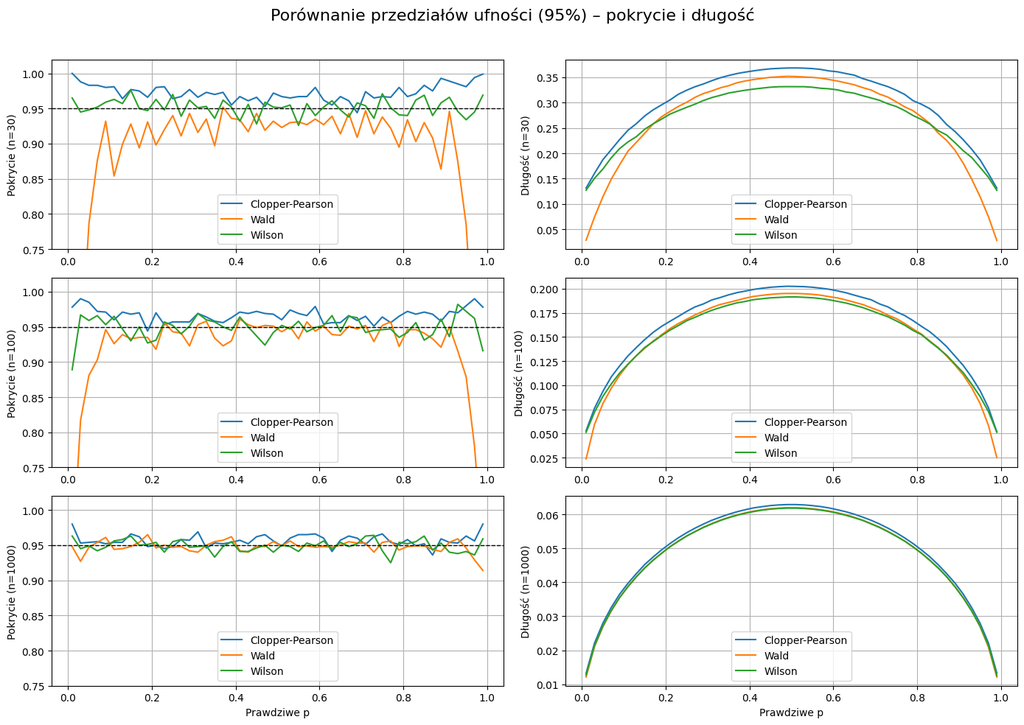

```python
# Parametry symulacji
confidence_zad_9 = 0.95
alpha_zad_9 = 1 - confidence_zad_9
n_values_zad_9 = [30, 100, 1000]
p_values_zad_9 = np.linspace(0.01, 0.99, 50)
n_sim_zad_9 = 1000

methods_zad_9 = {
    'Clopper-Pearson': 'beta',
    'Wald': 'normal',
    'Wilson': 'wilson'
}

results_zad_9 = {}

# Symulacje
for n_zad_9 in n_values_zad_9:
    results_zad_9[n_zad_9] = {}
    for method_name_zad_9, method_zad_9 in methods_zad_9.items():
        coverages_zad_9 = []
        lengths_zad_9 = []
        for p_zad_9 in p_values_zad_9:
            cover_zad_9 = 0
            length_list_zad_9 = []
            for _ in range(n_sim_zad_9):
                x_zad_9 = np.random.binomial(n_zad_9, p_zad_9)
                ci_low_zad_9, ci_high_zad_9 = proportion_confint(x_zad_9, n_zad_9, alpha=alpha_zad_9, method=method_zad_9)
                length_list_zad_9.append(ci_high_zad_9 - ci_low_zad_9)
                if ci_low_zad_9 <= p_zad_9 <= ci_high_zad_9:
                    cover_zad_9 += 1
            coverage_prob_zad_9 = cover_zad_9 / n_sim_zad_9
            avg_length_zad_9 = np.mean(length_list_zad_9)

            coverages_zad_9.append(coverage_prob_zad_9)
            lengths_zad_9.append(avg_length_zad_9)

        results_zad_9[n_zad_9][method_name_zad_9] = {
            'coverage': coverages_zad_9,
            'length': lengths_zad_9
        }

# Wykresy
fig, axs = plt.subplots(len(n_values_zad_9), 2, figsize=(14, 10), sharex=True)
fig.suptitle("Porównanie przedziałów ufności (95%) – pokrycie i długość", fontsize=16)

for i, n in enumerate(n_values_zad_9):
    # Pokrycie
    for method_name in methods_zad_9:
        axs[i, 0].plot(p_values_zad_9, results_zad_9[n][method_name]['coverage'], label=method_name)
    axs[i, 0].axhline(y=confidence_zad_9, color='black', linestyle='--', linewidth=1)
    axs[i, 0].set_ylabel(f"Pokrycie (n={n})")
    axs[i, 0].set_ylim(0.75, 1.02)
    axs[i, 0].legend(loc='lower center')
    axs[i, 0].grid(True)

    # Długość
    for method_name in methods_zad_9:
        axs[i, 1].plot(p_values_zad_9, results_zad_9[n][method_name]['length'], label=method_name)
    axs[i, 1].set_ylabel(f"Długość (n={n})")
    axs[i, 1].legend(loc='lower center')
    axs[i, 1].grid(True)

axs[-1, 0].set_xlabel("Prawdziwe p")
axs[-1, 1].set_xlabel("Prawdziwe p")
for ax_row in axs:
    for ax in ax_row:
        ax.tick_params(labelbottom=True)

plt.tight_layout(rect=[0, 0, 1, 0.96])
plt.show()
```

### Wnioski

#### Pokrycie

- Clopper-Pearson  
  pokrycie jest praktycznie cały czas większe niż 0.95. Oznacza to, że metoda jest konserwatywna – przedziały są "zbyt bezpieczne", tzn. mogą być zbyt szerokie. Wraz z wzrostem $n$, zbliża się do wartości 0.95. Jednak już dla małych próbek daje zbliżone wartości.
- Wald  
  pokrycie jest często niższe niż 0.95. Dzieje się tak szczególnie w przypadku małych próbek ($n=30$) oraz dla wartości $p$ bliskich 0 i 1. Dla dużej próbki ($n=1000$) pokrycie wypada dobrze, chociaż również posiada niższe wartości przy wartościach $p$ bliskich 0 i 1. Nie są jednak tak znaczące jak w przypadku mniejszej próbki.
- Wilson  
  pokrycie jest bardzo zbliżone do 0.95 w całym zakresie $p$. W tym przypadku również im większa próbka, tym lepsze rezultaty.

#### Długość przedziału

- Clopper-Pearson  
  przedziały są najdłuższe, co może prowadzić do mniejszej precyzji wyników. Jest to szczególnie widoczne przy małych próbkach. Również im większa próbka, tym węższy przedział.
- Wald  
  posiada najkrótsze przedziały. Jedynie przy wartościach $p$ bliskich 0.5 jest nieco szerszy niż przedział ufności Wilsona. Im większa próbka, tym bardziej te dwa przedziały są do siebie zbliżone długością. Jednak dla małych $n$ i wartościach $p$ bliskich 0 i 1 posiada bardzo wąskie przedziały (znacznie węższe niż Clopper-Pearson oraz Wilson).
- Wilson  
  przedziały są średniej długości – krótsze niż Clopper-Pearson, ale dłuższe niż Wald. Tutaj również zachodzi zależność, że wraz ze wzrostem $n$ spada długość przedziału.

#### Podsumowanie wniosków

Im większa próbka, tym:

- różnice między metodami się zmniejszają,
- wszystkie metody stają się bardziej precyzyjne.

Dla małych prób lepiej używać Wilson lub Clopper-Pearson, ponieważ dają dobre rezultaty w całym zakresie $p$. W przypadku Walda przy małym $n$ oraz wartościach $p$ bliskich 0 i 1 przedziały są bardzo wąskie oraz występuje bardzo duże niedoszacowanie przy pokryciu.  
Ostatecznie Wilson wydaje się być najlepszym wyborem, ponieważ działa najbardziej ogólnie.

# CZĘŚĆ V

## Zadanie 10

```python
k = 15
n = 25
p = 0.5
alpha = 0.05 # przyjęty poziom istotności

# różne hipotezy alternatywne
alternatives = ['two-sided', 'greater', 'less']

# scipy.stats.binomtest
for alternative in alternatives:
    print(f"Test dla hipotezy alternatywnej {alternative}: ")
    test = scipy.stats.binomtest(k, n, p, alternative)
    print(f"Liczba sukcesów: {test.k}, liczba prób: {test.n}, wartość statystyki testowej: {test.statistic}, p-wartość: {test.pvalue}")
    if test.pvalue <= alpha:
        print(f"Odrzucenie hipotezy zerowej.")
    else:
        print("Nie ma podstaw do odrzucenia hipotezy zerowej.")
```

```
Test dla hipotezy alternatywnej two-sided:
Liczba sukcesów: 15, liczba prób: 25, wartość statystyki testowej: 0.6, p-wartość: 0.42435622215270996
Nie ma podstaw do odrzucenia hipotezy zerowej.
Test dla hipotezy alternatywnej greater:
Liczba sukcesów: 15, liczba prób: 25, wartość statystyki testowej: 0.6, p-wartość: 0.21217811107635498
Nie ma podstaw do odrzucenia hipotezy zerowej.
Test dla hipotezy alternatywnej less:
Liczba sukcesów: 15, liczba prób: 25, wartość statystyki testowej: 0.6, p-wartość: 0.885238528251648
Nie ma podstaw do odrzucenia hipotezy zerowej.
```

```python
k = 1500
n = 2500
p = 0.5
alpha = 0.05
alternatives = ['two-sided', 'smaller', 'larger']

for alternative in alternatives:
    print(f"Test dla hipotezy alternatywnej {alternative}: ")
    z_stat, p_value = proportions_ztest(k, n, value = p, alternative = alternative)
    print(f"wartość statystyki testowej: {z_stat}, p-wartość: {p_value}")
    if p_value <= alpha:
        print(f"Odrzucenie hipotezy zerowej.")
    else:
        print("Nie ma podstaw do odrzucenia hipotezy zerowej.")
```

```
Test dla hipotezy alternatywnej two-sided:
wartość statystyki testowej: 10.206207261596573, p-wartość: 1.8599351718598843e-24
Odrzucenie hipotezy zerowej.
Test dla hipotezy alternatywnej smaller:
wartość statystyki testowej: 10.206207261596573, p-wartość: 1.0
Nie ma podstaw do odrzucenia hipotezy zerowej.
Test dla hipotezy alternatywnej larger:
wartość statystyki testowej: 10.206207261596573, p-wartość: 9.299675859299421e-25
Odrzucenie hipotezy zerowej.
```

## Zadanie 11

```python
alpha = 0.05
n = len(data)

# 1. Prawdopodobieństwo, że w firmie pracuje kobieta
print("Sprawdzenie hipotezy: Prawdopodobieństwo, że w firmie pracuje kobieta, wynosi 0.5.")

p = 0.5
k_1 = (data["PŁEĆ"] == "K").sum()

test_1 = scipy.stats.binomtest(k_1, n, p, 'two-sided')
print("P-wartość: ", test_1.pvalue)

if test_1.pvalue <= 0.05:
    print(f"Odrzucenie hipotezy zerowej.")
else:
    print("Nie ma podstaw do odrzucenia hipotezy zerowej.")
```

```
Sprawdzenie hipotezy: Prawdopodobieństwo, że w firmie pracuje kobieta, wynosi 0.5.
P-wartość:  4.97297347921355e-05
Odrzucenie hipotezy zerowej.
```

Porównanie p-wartości obliczonej za pomocą funkcji scipy.stats.binomtest z przyjętym na początku zadania poziomem ufności pozwoliło na odrzucenie hipotezy zerowej i przyjęcie hipotezy alternatywnej. Oznacza to, że prawdopodobieństwo, że w firmie pracuje kobieta, nie jest równe 0.5. Zgadza się to z obserwacjami z części pierwszej, gdzie odnotowano dysproporcję pomiędzy liczbą kobiet i mężczyzn zatrudnionych w firmie.

```python
# 2. Prawdopodobieństwo, że pracownik uważa szkolenia za przystosowane do swoich potrzeb w pierwszym badanym okresie jest większe bądź równe 0.7.
print("Sprawdzenie hipotezy: Prawdopodobieństwo, że pracownik uważa szkolenia za przystosowane do swoich potrzeb w pierwszym badanym okresie jest większe bądź równe 0.7.")

p_2 = 0.7
k_2 = (data["PYT_2"] == 1).sum() + (data["PYT_2"] == 2).sum()
test_2 = scipy.stats.binomtest(k_2, n, p_2, 'less')
print("P-wartość: ", test_2.pvalue)

if test_2.pvalue <= 0.05:
    print(f"Odrzucenie hipotezy zerowej.")
else:
    print("Nie ma podstaw do odrzucenia hipotezy zerowej.")
```

```
Sprawdzenie hipotezy: Prawdopodobieństwo, że pracownik uważa szkolenia za przystosowane do swoich potrzeb w pierwszym badanym okresie jest większe bądź równe 0.7.
P-wartość:  3.212876740960112e-07
Odrzucenie hipotezy zerowej.
```

Porównanie p-wartości obliczonej za pomocą funkcji scipy.stats.binomtest z przyjętym na początku zadania poziomem ufności pozwoliło na odrzucenie hipotezy zerowej i przyjęcie hipotezy alternatywnej, co oznacza, że prawdopodobieństwo, że pracownik uważa szkolenia za przystosowane do swoich potrzeb w pierwszym badanym okresie, jest mniejsze niż 0,7. To również zgadza się z obserwacjami z części pierwszej - z wykresów można odczytać, że opinie zdecydowanie pozytywne oraz pozytywne stanowią 53% wszystkich opinii.

```python
# 3. Prawdopodobieństwo, że kobieta pracuje na stanowisku kierowniczym jest równe prawdopodobieństwu, że mężczyzna pracuje na stanowisku kierowniczym.
print("Sprawdzenie hipotezy: Prawdopodobieństwo, że kobieta pracuje na stanowisku kierowniczym jest równe prawdopodobieństwu, że mężczyzna pracuje na stanowisku kierowniczym.")

female_n = (data["PŁEĆ"] == "K").sum()
female_leaders = ((data["PŁEĆ"] == "K") & (data["CZY_KIER"] == "Tak")).sum()
male_n = (data["PŁEĆ"] == "M").sum()
male_leaders = ((data["PŁEĆ"] == "M") & (data["CZY_KIER"] == "Tak")).sum()

k_3 = [female_leaders, male_leaders] # liczba sukcesów
n_3 = [female_n, male_n] # liczba prób

stat_3, p_value_3 = proportions_ztest(k_3, n_3, alternative='two-sided')
print("P-wartość: ", p_value_3)

if p_value_3 <= 0.05:
    print(f"Odrzucenie hipotezy zerowej.")
else:
    print("Nie ma podstaw do odrzucenia hipotezy zerowej.")
```

```
Sprawdzenie hipotezy: Prawdopodobieństwo, że kobieta pracuje na stanowisku kierowniczym jest równe prawdopodobieństwu, że mężczyzna pracuje na stanowisku kierowniczym.
P-wartość:  0.49309035250452393
Nie ma podstaw do odrzucenia hipotezy zerowej.
```

Porównanie p-wartości z przyjętym poziomem ufności nie wykazało podstaw do odrzucenia hipotezy zerowej. Oznacza to, że prawdopodobieństwo, że kobieta pracuje na stanowisku kierowniczym, może być równe prawdopodobieństwu, że mężczyzna pracuje na stanowisku kierowniczym.

```python
# 4. Prawdopodobieństwo, że kobieta uważa szkolenia za przystosowane do swoich potrzeb w pierwszym badanym okresie jest równe prawdopodobieństwu, że mężczyzna uważa szkolenia za przystosowane do swoich potrzeb
# w pierwszym badanym okresie.
print("Sprawdzenie hipotezy: Prawdopodobieństwo, że kobieta uważa szkolenia za przystosowane do swoich potrzeb w pierwszym badanym okresie jest równe prawdopodobieństwu, że mężczyzna uważa szkolenia za przystosowane do swoich potrzeb w pierwszym badanym okresie.")

female_n = (data["PŁEĆ"] == "K").sum()
female_k = ((data["PŁEĆ"] == "K") & (data["PYT_2"] == 1)).sum() + ((data["PŁEĆ"] == "K") & (data["PYT_2"] == 2)).sum()
male_n = (data["PŁEĆ"] == "M").sum()
male_k = ((data["PŁEĆ"] == "M") & (data["PYT_2"] == 1)).sum() + ((data["PŁEĆ"] == "M") & (data["PYT_2"] == 2)).sum()

k_4 = [female_k, male_k] # liczba sukcesów
n_4 = [female_n, male_n] # liczba prób

stat_4, p_value_4 = proportions_ztest(k_4, n_4, alternative='two-sided')
print("P-wartość: ", p_value_4)

if p_value_4 <= 0.05:
    print(f"Odrzucenie hipotezy zerowej.")
else:
    print("Nie ma podstaw do odrzucenia hipotezy zerowej.")
```

```
Sprawdzenie hipotezy: Prawdopodobieństwo, że kobieta uważa szkolenia za przystosowane do swoich potrzeb w pierwszym badanym okresie jest równe prawdopodobieństwu, że mężczyzna uważa szkolenia za przystosowane do swoich potrzeb w pierwszym badanym okresie.
P-wartość:  0.6293763135675485
Nie ma podstaw do odrzucenia hipotezy zerowej.
```

Porównanie p-wartości z przyjętym poziomem ufności nie wykazało podstaw do odrzucenia hipotezy zerowej, dlatego prawdopodobieństwo, że kobieta uważa szkolenia za przystosowane do swoich potrzeb w pierwszym badanym okresie, może być równe prawdopodobieństwu, że mężczyzna uważa szkolenia za przystosowane do swoich potrzeb w pierwszym badanym okresie.

```python
# 5. Prawdopodobieństwo, że kobieta pracuje w dziale zasobów ludzkich jest większe lub równe prawdopodobieństwu, że mężczyzna pracuje w dziale zasobów ludzkich.
print("Sprawdzenie hipotezy: Prawdopodobieństwo, że kobieta pracuje w dziale zasobów ludzkich jest większe lub równe prawdopodobieństwu, że mężczyzna pracuje w dziale zasobów ludzkich.")

female_n = (data["PŁEĆ"] == "K").sum()
female_k = ((data["PŁEĆ"] == "K") & (data["DZIAŁ"] == "HR")).sum()
male_n = (data["PŁEĆ"] == "M").sum()
male_k = ((data["PŁEĆ"] == "M") & (data["DZIAŁ"] == "HR")).sum()

k_5 = [female_k, male_k] # liczba sukcesów
n_5 = [female_n, male_n] # liczba prób

stat_5, p_value_5 = proportions_ztest(k_5, n_5, alternative='smaller')
print("P-wartość: ", p_value_5)

if p_value_5 <= 0.05:
    print(f"Odrzucenie hipotezy zerowej.")
else:
    print("Nie ma podstaw do odrzucenia hipotezy zerowej.")
```

```
Sprawdzenie hipotezy: Prawdopodobieństwo, że kobieta pracuje w dziale zasobów ludzkich jest większe lub równe prawdopodobieństwu, że mężczyzna pracuje w dziale zasobów ludzkich.
P-wartość:  0.00211649579963765
Odrzucenie hipotezy zerowej.
```

Porównanie p-wartości z przyjętym poziomem ufności wykazało podstawy do odrzucenia hipotezy zerowej i przyjęcia hipotezy alternatywnej. Oznacza to, że prawdopodobieństwo, że kobieta pracuje w dziale zasobów ludzkich jest mniejsze niż prawdopodobieństwo, że mężczyzna pracuje w dziale zasobów ludzkich.

## Zadanie 12

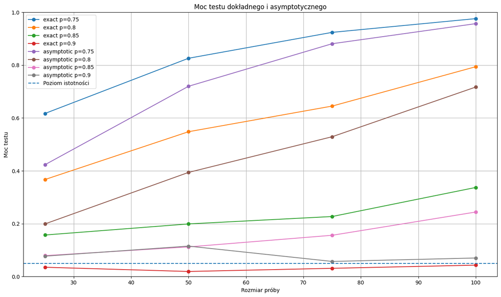

```python
p_0 = 0.9
p_alternative_values = np.arange(0.75, 0.91, 0.05)
n_values = [25, 50, 75, 100]
simulation_number = 1000
alpha = 0.05

simulation_results = {}

for p_alternative in p_alternative_values:

    simulation_results[p_alternative] = {'exact': [], 'asymptotic': []}
    for n in n_values:

        successes_number = np.random.binomial(n, p_alternative, size=simulation_number)
        rejections_number_exact = 0
        rejections_number_asymptotic = 0

        for x in successes_number:
            test = scipy.stats.binomtest(x, n, p=p_0, alternative='two-sided')
            if test.pvalue < alpha:
                rejections_number_exact += 1

        for x in successes_number:
            statistics, p_value = proportions_ztest(x, n, p_0, alternative='two-sided')
            if p_value < alpha:
                rejections_number_asymptotic += 1

        power_exact = rejections_number_exact/simulation_number
        power_asymptotic = rejections_number_asymptotic/simulation_number

        simulation_results[p_alternative]['exact'].append(power_exact)
        simulation_results[p_alternative]['asymptotic'].append(power_asymptotic)

plt.figure(figsize=(16, 9))
for test_type in ['exact', 'asymptotic']:
    for p_alternative in p_alternative_values:
        plt.plot(n_values, simulation_results[p_alternative][test_type], marker='o', label=f"{test_type} p={round(p_alternative, 2)}")


plt.axhline(alpha, linestyle='--', label="Poziom istotności")
plt.title("Moc testu dokładnego i asymptotycznego")
plt.xlabel("Rozmiar próby")
plt.ylabel("Moc testu")
plt.ylim(0, 1)
plt.legend()
plt.grid()
plt.show()
```

Z wykresu można odczytać, że im większy rozmiar próby, tym większa moc testu. Ponadto moc testu jest większa w przypadku testów dokładnych niż asymptotycznych. Można zauważyć również, że im większa jest różnica pomiędzy $p_0 = 0.9$ a zaproponowaną alternatywą, tym większa jest moc testu.

# CZĘŚĆ DODATKOWA

```python
def logit_transformation(p):
    return np.log(p/(1 - p))

def inversed_logit_transformation(theta):
    return 1/(1+np.exp(-theta))

def delta_logit_transformation_confidence_interval(k, n, alpha=0.05):

    estimated_p = k/n
    estimated_theta = logit_transformation(estimated_p)

    interval = np.sqrt(1/(n*estimated_p*(1 - estimated_p)))
    z_quantile = scipy.stats.norm.ppf(1 - alpha/2)

    confidence_interval_lower = estimated_theta - z_quantile*interval
    confidence_interval_upper = estimated_theta + z_quantile*interval

    return (inversed_logit_transformation(confidence_interval_lower), inversed_logit_transformation(confidence_interval_upper))

k = 40
n = 100
confidence_interval_delta_method = delta_logit_transformation_confidence_interval(k, n)

# Porównanie z wybraną funkcją
wilson_confidence_interval = statsmodels.api.stats.proportion_confint(count=k, nobs=n, method='wilson')

print(f"Przedział ufności, uzyskany za pomocą metody delta: {confidence_interval_delta_method[0]}, {confidence_interval_delta_method[1]}")
print(f"Przedział Wilsona z pakietu statsmodels.api:   {wilson_confidence_interval}")
```

```
Przedział ufności, uzyskany za pomocą metody delta: 0.3088414773152751, 0.4986527194910902
Przedział Wilsona z pakietu statsmodels.api:   (0.30940128643245896, 0.49799741320893826)
```

Zaimplementowana metoda delta oraz metoda Wilsona z funkcji statsmodels.api.stats.proportion_confint zwróciły zbliżone wyniki, co potwierdza poprawność implementacji.